# 7. Marginal structural model

# 3 MSM with time (R)

## R code

- `ipwtm(exposure, family, link, numerator = NULL, denominator, id, tstart, timevar, type, data, )`
  - **exposure, family, link, numerator, denominator, data** same as ipwpoint
  - **id**…identifies the cluster/subject where multiple measurements were made (indicate which observation come from the subject)
  - **tstart**…the start time of the follow-up intervals, only needed when family = “survival” (tstart should be < 0 for the first interval  
    => usually start from time 0 in actual dataset => subtract that by 100 or 1 to make sure it’s <1 and model know its first time point
  - **timevar**… follow-up time. When family = “survival”, it specifies the end time of the follow-up intervals
  - **type**…the type of exposure. Type = “first” estimates weights up to the first switch of the exposure value (e.g., for death, from 0 to 1) then keep constant afterwards. Alternative is type = “all” that weights were estimated at all time points.

## Example

- Dataset from ipw package, can be loaded by `data(haartdat)`
  - 1200 HIV patients was followed every 100 days since HIV seroconversion
  - HAART therapy are initiated which may depend on CD4 counts
    - tstart, fuptime: start and end of the follow-up interval
    - haartind: indicate whether HAART therapy was initiated in the follow-up interval (treatment)
    - event: indicator of death at the end of the interval
    - age: age at the start of follow-up year
    - cd4.sqrt: square root of the CD4 counts

## 1 Cox regression (not handling confounding)

1. Fitting a standard time-dependent Cox regression (not handling confounding)

```r
data(haartdat)
#patient 18 as example
haartdat[haartdat$patient==18,] #This patient dropout of the study at day 600
haartdat[haartdat$patient==63,] #This patient died at day 1100 (without initiation of HAART)
#Note this is different from interval censoring (only have the last row) we encountered before
#Use this to record every interval coz cd4 count can change and treatment can start at any interval
```

```
##     patient tstart fuptime haartind event sex age cd4.sqrt endtime dropout
## 465      18   -100       0        0     0   0  49 25.67100     600       0
## 466      18      0     100        0     0   0  49 30.34798     600       0
## 467      18    100     200        0     0   0  49 20.85665     600       0
## 468      18    200     300        0     0   0  49 23.55844     600       0
## 469      18    300     400        0     0   0  49 24.06242     600       0
## 470      18    400     500        0     0   0  49 24.95997     600       0
## 471      18    500     600        0     0   0  49 26.58947     600       1
##      patient tstart fuptime haartind event sex age cd4.sqrt endtime dropout
## 1030      63   -100       0        0     0   0  22 21.49419    1100       0
## 1031      63      0     100        0     0   0  22 16.88194    1100       0
## 1032      63    100     200        0     0   0  22 18.68154    1100       0
## 1033      63    200     300        0     0   0  22 23.00000    1100       0
## 1034      63    300     400        0     0   0  22 22.60531    1100       0
## 1035      63    400     500        0     0   0  22 22.75961    1100       0
## 1036      63    500     600        0     0   0  22 18.27567    1100       0
## 1037      63    600     700        0     0   0  22 20.68816    1100       0
## 1038      63    700     800        0     0   0  22 20.54264    1100       0
## 1039      63    800     900        0     0   0  22 18.08314    1100       0
## 1040      63    900    1000        0     0   0  22 16.88194    1100       0
## 1041      63   1000    1100        0     1   0  22 16.43168    1100       0
```

```r
### 1 Fitting a standard time-dependent Cox regression (not handling confounding)
cox0 <- coxph(Surv(tstart, fuptime, event) ~ haartind + age + sex + cd4.sqrt + cluster(patient), data = haartdat) #cluter coz from the same patient
summary(cox0)
#The estimated hazard ratio of patients receiving HAART was 0.54 (95% CI 0.23 1.22), which is not statistically significant
```

```
## Call:
## coxph(formula = Surv(tstart, fuptime, event) ~ haartind + age +
##     sex + cd4.sqrt, data = haartdat, cluster = patient)
##
##   n= 19175, number of events= 31
##
##              coef exp(coef) se(coef) robust se      z Pr(>|z|)
## haartind -0.61994   0.53798  0.43837   0.41971 -1.477 0.139657
## age       0.05943   1.06123  0.01522   0.01657  3.588 0.000334 ***
## sex       0.04408   1.04507  0.47194   0.45187  0.098 0.922282
## cd4.sqrt -0.13125   0.87700  0.03440   0.04682 -2.803 0.005060 **
## ---
## Signif. codes:  0 '***' 0.001 '**' 0.01 '*' 0.05 '.' 0.1 ' ' 1
##
##          exp(coef) exp(-coef) lower .95 upper .95
## haartind     0.538     1.8588    0.2363    1.2247
## age          1.061     0.9423    1.0273    1.0963
## sex          1.045     0.9569    0.4310    2.5338
## cd4.sqrt     0.877     1.1403    0.8001    0.9613
##
## Concordance= 0.708  (se = 0.056 )
## Likelihood ratio test= 31.53  on 4 df,   p=2e-06
## Wald test            = 25.36  on 4 df,   p=4e-05
## Score (logrank) test = 33.72  on 4 df,   p=8e-07,   Robust = 12.13  p=0.02
##
##   (Note: the likelihood ratio and score tests assume independence of
##      observations within a cluster, the Wald and robust score tests do not).
```

## 2a Weight for endogenous confounding

2a. Estimate the weights (Handle time-dependent confounding CD4 count)

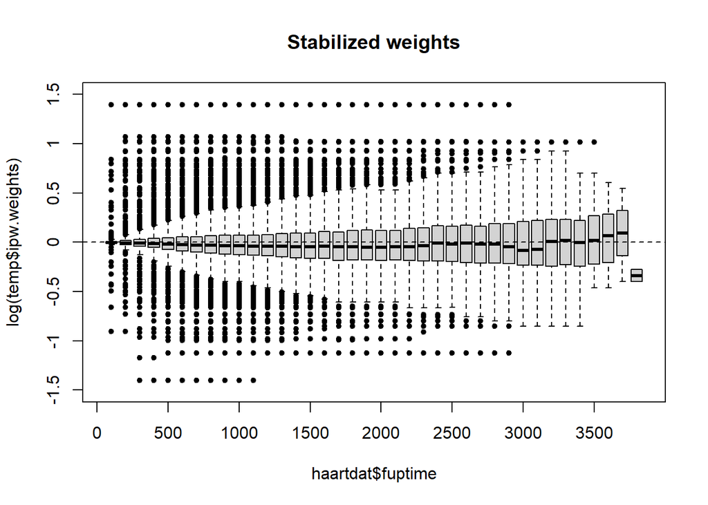

```r
### 2a Estimate the weights (Handle time-dependent confounding CD4 count)
## stabalized weight (numerator = time-independent confounding; denominator = time-dependent confounding)
temp <- ipwtm(exposure = haartind, family = "survival",
              numerator = ~ sex + age, denominator = ~ cd4.sqrt + sex + age,
              id = patient, tstart = tstart, timevar = fuptime, type = "first", data = haartdat)
## unstabalized weight (remove numerator element)
temp.uns <- ipwtm(exposure = haartind, family = "survival",
                  denominator = ~ cd4.sqrt + sex + age, id = patient, tstart = tstart,
                  timevar = fuptime, type = "first", data = haartdat)
## Comparison: distribution of Log stabalized and unstabalized weight in diff time point can be displayed by ipwplot()
ipwplot(weights = temp$ipw.weights, timevar = haartdat$fuptime,
        binwidth = 100, ylim = c(-1.5, 1.5), main = "Stabilized weights",
        xaxt = "n", yaxt = "n")
axis(side = 1, at = 0:7*5, labels = 0:7*500)
axis(side = 2, at = -3:3*0.5, labels = -3:3*0.5) #mean around 0 coz before log, most weights are 1
```

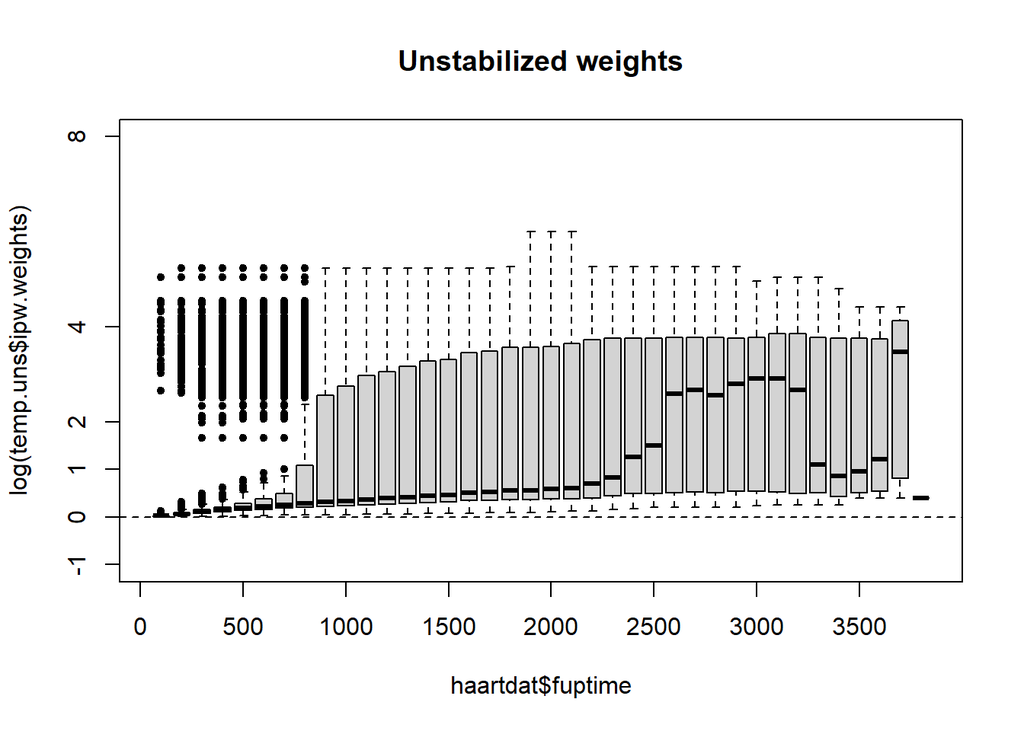

```r
ipwplot(weights = temp.uns$ipw.weights, timevar = haartdat$fuptime,
        binwidth = 100, ylim = c(-1, 8), main = "Unstabilized weights",
        xaxt = "n", yaxt = "n")
axis(side = 1, at = 0:7*5, labels = 0:7*500)
axis(side = 2, at = c(-1:2,4,8), labels = c(-1:2,4,8))
```

```r
## Comparing stabilized vs unstabilized weights
summary(temp$ipw.weights) #stabalized weight max 7
summary(temp.uns$ipw.weights) #unstabalized weight max 400 => issue in analysis
#Unstabilized weights have a much larger variation
```

```
##    Min. 1st Qu.  Median    Mean 3rd Qu.    Max.
##  0.2459  0.9036  0.9862  1.0390  1.0611  7.1257
##    Min. 1st Qu.  Median    Mean 3rd Qu.    Max.
##   1.003   1.160   1.372  13.161  15.401 406.338
```

## 2b Weight for dropout

2b. Estimate the weights (Handle informative censoring – dropout)

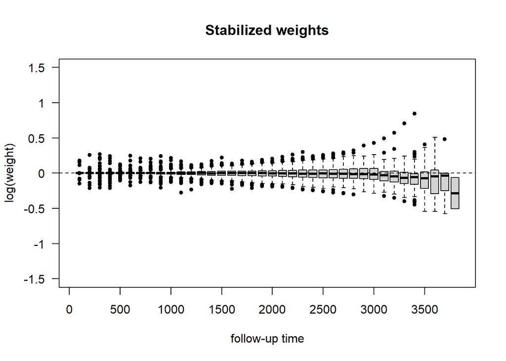

```r
### 2b Estimate the stabalized weights (Handle informative censoring -- dropout)
temp2 <- ipwtm(exposure = dropout, family = "survival",
               numerator = ~ sex + age, denominator = ~ cd4.sqrt + sex + age,
               id = patient, tstart = tstart, timevar = fuptime, type = "first", data = haartdat)
ipwplot(weights = temp2$ipw.weights, timevar = haartdat$fuptime, binwidth = 100,
        ylim = c(-1.5, 1.5), main = "Stabilized weights", xaxt = "n", yaxt = "n",
        xlab="follow-up time", ylab="log(weight)")
axis(side = 1, at = 0:7*5, labels = 0:7*500)
axis(side = 2, at = -3:3*0.5, labels = -3:3*0.5, las=1)
```

```r
#The weight is quite stable.
## unstabalized weight
temp2.uns <- ipwtm(exposure = dropout, family = "survival",
                   denominator = ~ cd4.sqrt + sex + age, id = patient,
                   tstart = tstart, timevar = fuptime, type = "first", data = haartdat)
```

## 3 Estimate

Fitting MSM

- Robust (sandwich) standard error was used to account for the correlation among patient
  - Provided when using coxph with cluster() to specify correlated observations

```r
## Estimate from stabalized weight
require(survival)
summary(coxph(Surv(tstart, fuptime, event) ~ haartind + cluster(patient), data = haartdat,
              weights = temp$ipw.weights*temp2$ipw.weights)) #multiply weights tgt; don't include age, sex, cd4 count coz alr handled by weighting
```

```
## Call:
## coxph(formula = Surv(tstart, fuptime, event) ~ haartind, data = haartdat,
##     weights = temp$ipw.weights * temp2$ipw.weights, cluster = patient)
##
##   n= 19175, number of events= 31
##
##             coef exp(coef) se(coef) robust se      z Pr(>|z|)
## haartind -0.9378    0.3915   0.4300    0.4524 -2.073   0.0382 *
## ---
## Signif. codes:  0 '***' 0.001 '**' 0.01 '*' 0.05 '.' 0.1 ' ' 1
##
##          exp(coef) exp(-coef) lower .95 upper .95
## haartind    0.3915      2.554    0.1613    0.9501
##
## Concordance= 0.597  (se = 0.029 )
## Likelihood ratio test= 5.59  on 1 df,   p=0.02
## Wald test            = 4.3  on 1 df,   p=0.04
## Score (logrank) test = 5.08  on 1 df,   p=0.02,   Robust = 4.85  p=0.03
##
##   (Note: the likelihood ratio and score tests assume independence of
##      observations within a cluster, the Wald and robust score tests do not).
```

```r
# The hazard ratio of patients receiving HAART was 0.39 (95% CI 0.16 0.95)
# The estimated effect is stronger than that from the Cox regression

## Estimate from unstabalized weight
summary(coxph(Surv(tstart, fuptime, event) ~ haartind + cluster(patient), data = haartdat,
              weights = temp.uns$ipw.weights*temp2.uns$ipw.weights))
```

```
## Call:
## coxph(formula = Surv(tstart, fuptime, event) ~ haartind, data = haartdat,
##     weights = temp.uns$ipw.weights * temp2.uns$ipw.weights, cluster = patient)
##
##   n= 19175, number of events= 31
##
##            coef exp(coef) se(coef) robust se     z Pr(>|z|)
## haartind 0.2929    1.3403   0.1213    0.5953 0.492    0.623
##
##          exp(coef) exp(-coef) lower .95 upper .95
## haartind      1.34     0.7461    0.4173     4.305
##
## Concordance= 0.503  (se = 0.015 )
## Likelihood ratio test= 6.38  on 1 df,   p=0.01
## Wald test            = 0.24  on 1 df,   p=0.6
## Score (logrank) test = 5.87  on 1 df,   p=0.02,   Robust = 0.2  p=0.7
##
##   (Note: the likelihood ratio and score tests assume independence of
##      observations within a cluster, the Wald and robust score tests do not).
```

```r
# The 95% CI is much wider (0.42, 4.31). Too much variation cannot give u accurate reuslt => using stabalized weight is important.
```

# 4 Review

## Model diagnositcs

- Assumption 1: Unconfoundedness between treatment and predictors
  - Not testable
  1. More likely by identifying and including relevant confounders from the **literature** (diligently)
  2. Perform **sensitivity analysis** by including other potential confounders
- Assumption 2: Experimental treatment assignment / structural positivity
  - Plot the distribution of the stabilized weight, see whether **extreme values** indicate potential violation of positivity (see if extreme value is too big)
  - **Mean value far away from 1** indicates model mis-specification
  - However, this is just simple guideline, cannot make too much indication…

## Review

Note: 1. use stabalized weight by indicating the “numerator” 2. do not include confounders in regression model, otherwise will doubly adjusted for them

# Real-life example

- Estimating the Time-Varying Joint Effects of Obesity and Smoking on All-Casue Mortality Uisng Marginal Structural Models by Banack et al. AJE, 2016
  - Objective: to estimate the joint effects of obesity and smoking on all-cause mortality
  - Study design: prospective longitudinal study
  - Subjects: 15,792 men and women aged 45 64 years old in the US
    - CVD is an endogenous confounder
    - Steps: First calculate the weight. Then fit a poisson regression.
    - Result: MSM estimated a relatively higher effect of obesity than from adj. model